# prac12

Ndivhuwo Nyase

2023-02-08

## Question 1

What is probability of getting the different winning symbols? 1.1 Spin the reel once. 1.2 Note the symbol. 1.3 Repeat 1 and 2 above many times (10000). 1.4 Take note of how many times each of the symbols appear. 1.5 Divide by 10000. This is an estimate of the probability.

```r
# Create the reel with the various probabililites
reel <- 1:6 #the different categories
probs <- c( 7, 5, 3, 6, 9, 20 )/50
spin <- sample(reel, size = 1, prob = probs)

payout_and_symbol <- function(spin) {


  if (spin==1)
  {
    payout<-2
    symbol<- 'hearts'
  } else if (spin==2)
  {
    payout<-2.5
    symbol <- 'diamonds'
  } else if (spin==3)
  {
    payout<-8
    symbol <- 'spades'
  }else if (spin==4)
  {
    payout<-4
    symbol <- 'clubs'
  } else if (spin==5)
  {
    payout<-2.5
    symbol <- 'joker'
  } else if (spin == 6)
  { payout <- 0
  symbol <- 'ca'
  }else {
    payout <- 0
    symbol <- FALSE}

  return(c(payout,symbol))
}
```

## QUESTION 1

```r
# Part 1
# 1.1 Spin the reel once.
spin <- sample(reel, size = 1, prob = probs)
spin
```

```
## [1] 5
```

```r
symbol<- payout_and_symbol(spin)
symbol[2]
```

```
## [1] "joker"
```

```r
spin_reel_nsim <- function(simulations,payout=FALSE,symbol=TRUE){
  i <- 0
  result <- c()
  while(i < simulations) {
    i <- i + 1
    spin <- sample(reel, size = 1, prob = probs, replace = TRUE)
    p_s <- payout_and_symbol(spin)
    if (symbol == TRUE & payout == FALSE)
    {
      result <- append(result,p_s[2])
    } else if (payout == TRUE & symbol == FALSE) {
      result <- append(result,p_s[1])
    } else if (payout == TRUE & symbol == TRUE) {
      result <- append(result,p_s)
    } else return('CHECK PARAMETERS')

  }

  return(result)
}

#1.3
part1 <- spin_reel_nsim(10000)


part1<-as.factor(part1)
# 1.4
tab <- table(part1)
tab
```

```
## part1
##       ca    clubs diamonds   hearts    joker   spades
##     4006     1181     1004     1404     1813      592
```

```r
# 1.5
nsim<-sum(as.vector(table(part1)))

probabilities <- (tab/nsim)*100
cbind(levels(part1),probabilities)
```

```
##                     probabilities
## ca       "ca"       "40.06"
## clubs    "clubs"    "11.81"
## diamonds "diamonds" "10.04"
## hearts   "hearts"   "14.04"
## joker    "joker"    "18.13"
## spades   "spades"   "5.92"
```

## QUESTION 2

Calculate the average pay out if you spin the reel once. - i.e. one ‘play’ of the game is to spin the reel once, and you play the game 10000 times. 2.1 Spin the reel once. 2.2 Note the symbol. 2.3 Note the payout – store it. 2.4 Repeat 1, 2 and 3 above many times (10000). 2.5 You should now have 10 000 payout values. 2.6 Calculate the mean of these values. This is an estimate of the average. payout if you play the game once. - Compare it to the true value!

```r
# Part 2
# 2.1
spin <- sample(reel, size = 1, prob = probs)
spin
```

```
## [1] 6
```

```r
#2.2 and 2.3
p_s <- payout_and_symbol(spin)
p_s[1]
```

```
## [1] "0"
```

```r
#2.4
part2 <- spin_reel_nsim(10000, payout = TRUE, symbol = FALSE)

part2f <- as.numeric(part2)

mean(part2f)
```

```
## [1] 1.93435
```

```r
#2.5
spin <- sample(reel, size = 10000, prob = probs, replace = TRUE)

true <- mean(probs[spin])
true
```

```
## [1] 0.23953
```

## QUESTION 3

Calculate the average total pay out if you spin the reel 10/100/1000 times - i.e. one ‘play’ of the game is to spin the reel 10/100/1000 times, and you play the game 10000 times. 3.1 Graphically display the average total pay out after 10/100/1000 plays of the game by means of histograms and box and whisker plots. 3.2 Describe the distribution of the average total pay out pay out for each case by calculating relevant summary statistics.

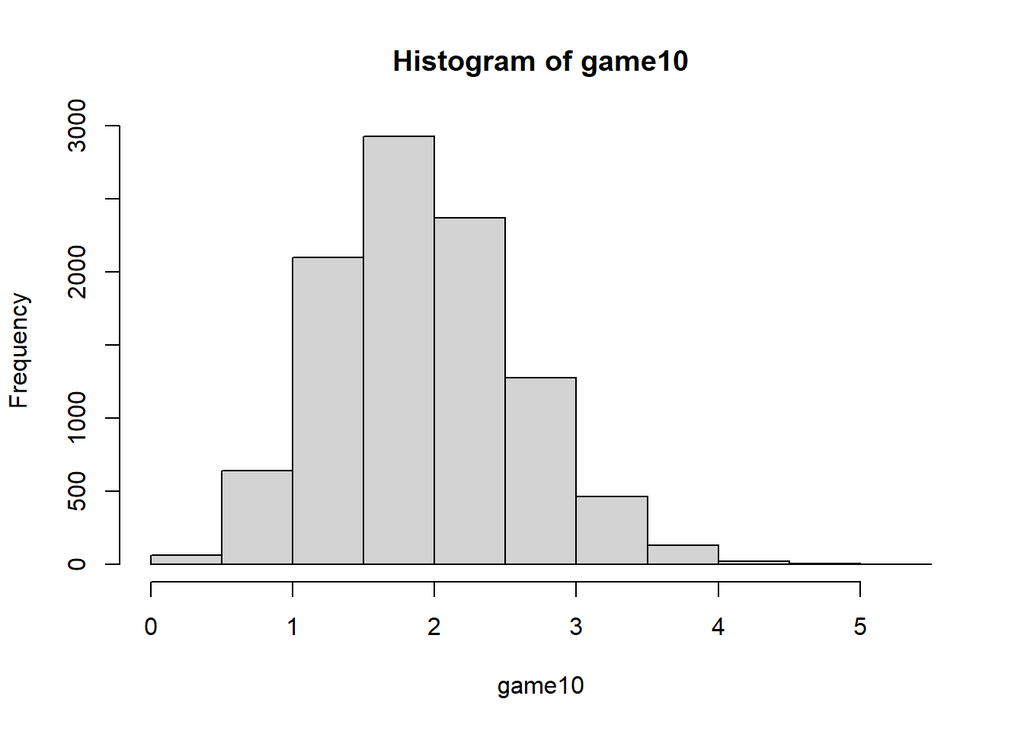

```r
ngames_func <- function(ngames, size_, payout_=TRUE, symbol_=FALSE){
  game_pay <- numeric(ngames)
  for (i in 1:ngames) {
    outs = as.numeric(spin_reel_nsim(size_,payout = payout_, symbol = symbol_ ))
    game_pay[i] <- mean(outs)
  }
  return(game_pay)
}

game10 <- ngames_func(10000,10,payout_ = TRUE,symbol_ = F)
hist(game10)
```

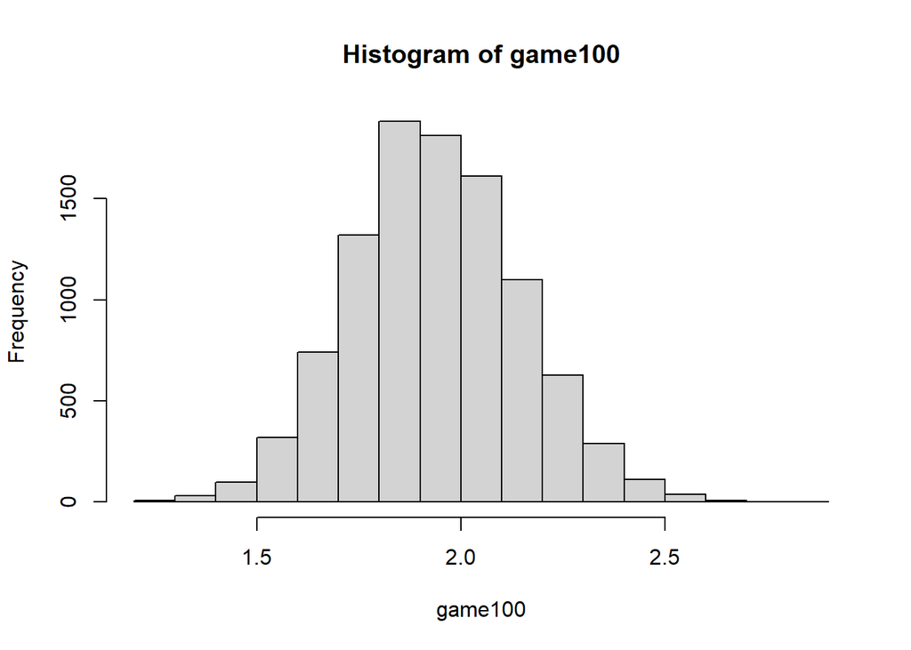

```r
game100 <- ngames_func(10000,100,payout_ = TRUE,symbol_ = F)
hist(game100)
```

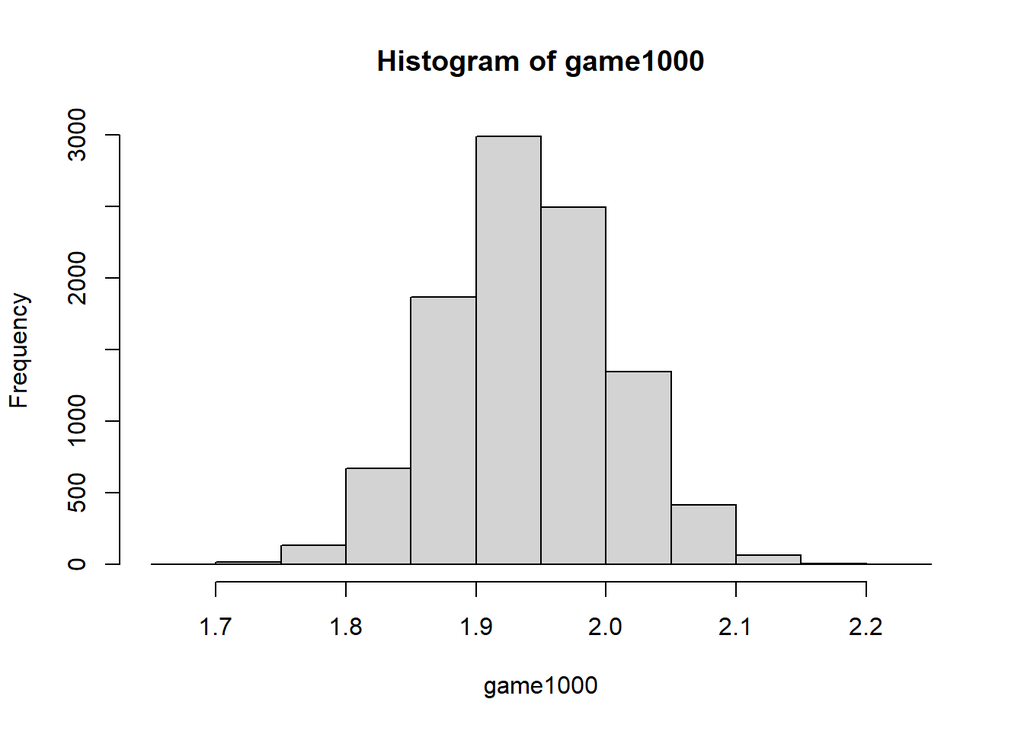

```r
game1000 <- ngames_func(10000,1000,payout_ = TRUE,symbol_ = F)
hist(game1000)
```

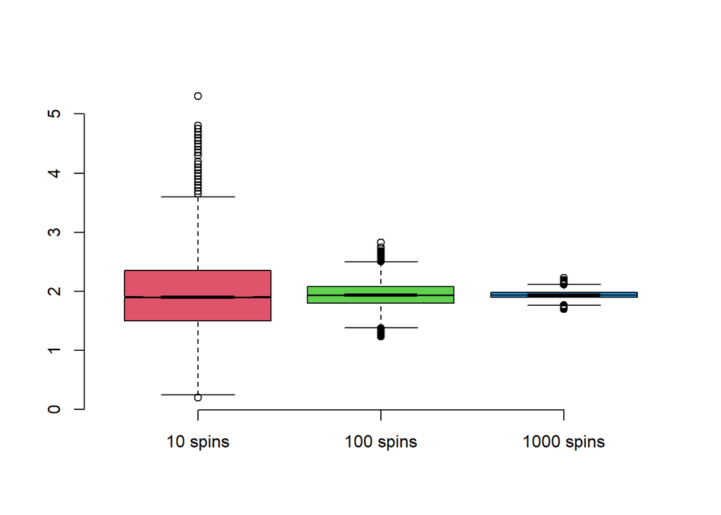

```r
boxplot(game10,game100,game1000, frame = FALSE,
        notch = TRUE, names = c('10 spins','100 spins', '1000 spins')
        , col =2:4 )
```

```r
all_games <- cbind(game10,game100,game1000)
summary(all_games)
```

```
##      game10         game100         game1000
##  Min.   :0.200   Min.   :1.235   Min.   :1.696
##  1st Qu.:1.500   1st Qu.:1.800   1st Qu.:1.897
##  Median :1.900   Median :1.935   Median :1.940
##  Mean   :1.947   Mean   :1.942   Mean   :1.940
##  3rd Qu.:2.350   3rd Qu.:2.080   3rd Qu.:1.984
##  Max.   :5.300   Max.   :2.825   Max.   :2.223
```

The distribution of game 100 and 1000 are more centred towards the mean due to cental limit theorom in which with a larger sample size, your sample mean is more likely to be close to the real population mean.